# Phenotypic clusterubg of EAPs

written by Jeon Lee on May 7, 2020; updated on September 24, 2020

$~$

#### Environment set-up and data import

```r
library(data.table)
library(factoextra)
library(ggplot2)
library(ggfortify)
library(knitr)
library(kableExtra)

setwd("./")

Sys.setenv(http_proxy="proxy.swmed.edu:3128")
Sys.setenv(https_proxy="proxy.swmed.edu:3128")

df <- read.table("EAP_Phenotype_Data.csv", sep=",", header = TRUE)

colnames(df) <- gsub( "\\.", "\\_", colnames(df))
rownames(df) <- df$EAP
df <- df[,-c(1)]
```

$~$

#### Visualization of proteins’ PCA plot and their distance matrix

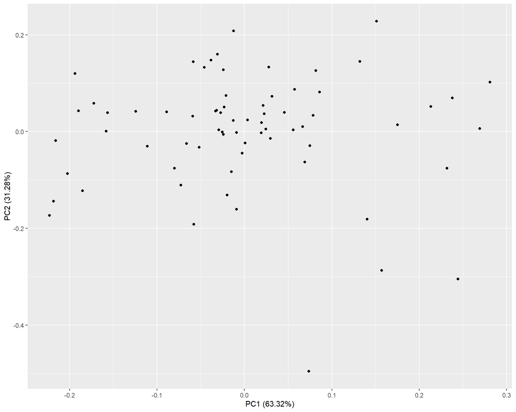

```r
df_pctDiff <- df

#PCA plot for df_pctDiff
autoplot(prcomp(df_pctDiff), data=df_pctDiff)
```

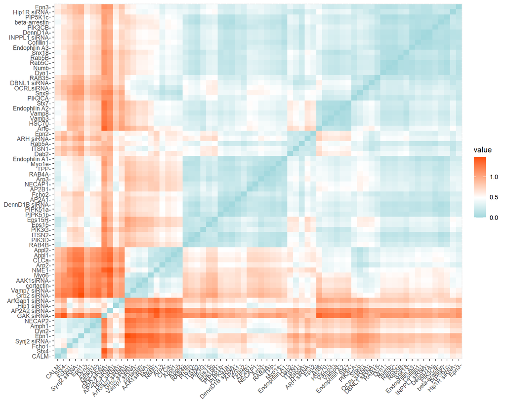

```r
#Visualize a distance matrix among proteins
distance <- get_dist(df_pctDiff, method = "euclidean") # "euclidean", "minkowski", "pearson", etc
fviz_dist(distance, gradient = list(low = "#00AFBB", mid = "white", high = "#FC4E07"))
```

**PCA plot:** About 94% of data variance can ben explained only with PC1 and PC2.

**Distance heatmap:** There seem to exist very obvious and a little bit less obvious clusters.

$~$

#### Gap statistic for optimal cluster number(K) search

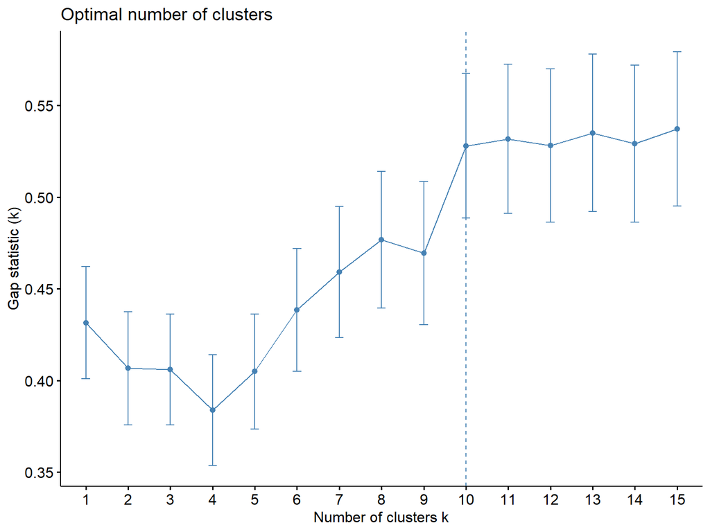

```r
res.km <- eclust(df_pctDiff, "kmeans", k = NULL, k.max = 15, nstart = 25, graph = FALSE, gap_maxSE = list(method = "globalSEmax", SE.factor = 1), seed=123) # if k = NULL, an optimal number searched by gap statistic is used

# Gap statistic plot
fviz_gap_stat(res.km$gap_stat, maxSE = list(method = "globalSEmax", SE.factor = 1))
```

**Automatic optimal k selection:** k=10 is automatically selected by a gap statistic analysis as an optimal cluster number.

$~$

#### K-means clustering (k=10)

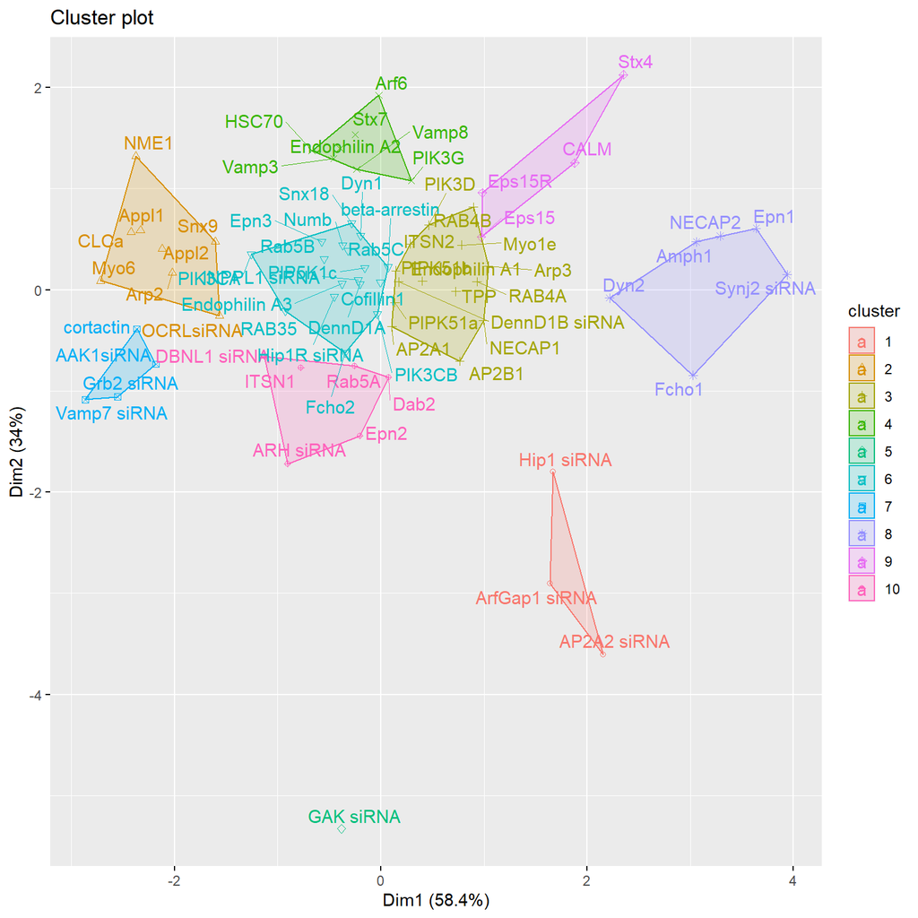

```r
K <- 10
res.km2 <- eclust(df_pctDiff, "kmeans", k = K, nstart = 25, graph = FALSE)
#fviz_silhouette(res.km2) # Silhouette plot
fviz_cluster(res.km2, data = myData, repel = TRUE, ellipse.type = "convex", show.clust.cent = FALSE)
```

```r
tb_km <- data.frame(sort(res.km2$cluster))
colnames(tb_km) <- "Cluster No."
kable(tb_km) %>% kable_styling("striped", full_width = F) %>% scroll_box(height = "400px")
```

|  | Cluster No. |
| --- | --- |
| Hip1 siRNA | 1 |
| AP2A2 siRNA | 1 |
| ArfGap1 siRNA | 1 |
| Arp2 | 2 |
| Myo6 | 2 |
| CLCa | 2 |
| OCRLsiRNA | 2 |
| Appl1 | 2 |
| Appl2 | 2 |
| NME1 | 2 |
| Snx9 | 2 |
| Arp3 | 3 |
| Myo1e | 3 |
| AP2A1 | 3 |
| AP2B1 | 3 |
| Endophilin A1 | 3 |
| RAB4A | 3 |
| RAB4B | 3 |
| PIK3D | 3 |
| PIPK51a | 3 |
| PIPK51b | 3 |
| DennD1B siRNA | 3 |
| ITSN2 | 3 |
| NECAP1 | 3 |
| TPP | 3 |
| Endophilin A2 | 4 |
| Arf6 | 4 |
| HSC70 | 4 |
| PIK3G | 4 |
| Stx7 | 4 |
| Vamp3 | 4 |
| Vamp8 | 4 |
| GAK siRNA | 5 |
| Cofillin1 | 6 |
| Hip1R siRNA | 6 |
| beta-arrestin | 6 |
| Numb | 6 |
| Dyn1 | 6 |
| Endophilin A3 | 6 |
| Epn3 | 6 |
| RAB35 | 6 |
| Rab5B | 6 |
| Rab5C | 6 |
| INPPL1 siRNA | 6 |
| PIK3CA | 6 |
| PIK3CB | 6 |
| PIP5K1c | 6 |
| DennD1A | 6 |
| Fcho2 | 6 |
| Snx18 | 6 |
| cortactin | 7 |
| AAK1siRNA | 7 |
| Grb2 siRNA | 7 |
| Vamp7 siRNA | 7 |
| Dyn2 | 8 |
| Amph1 | 8 |
| Epn1 | 8 |
| Fcho1 | 8 |
| NECAP2 | 8 |
| Synj2 siRNA | 8 |
| CALM | 9 |
| Eps15 | 9 |
| Eps15R | 9 |
| Stx4 | 9 |
| DBNL1 siRNA | 10 |
| ARH siRNA | 10 |
| Dab2 | 10 |
| Epn2 | 10 |
| Rab5A | 10 |
| ITSN1 | 10 |

**k-means clustering result:** Ten clusters, which are identified by the k-means clustering method, are marked on a PCA plot. Cluster numbers assgined to the proteins are listed in the table above.

$~$

#### APC(Affinity Propagation Clustering) method

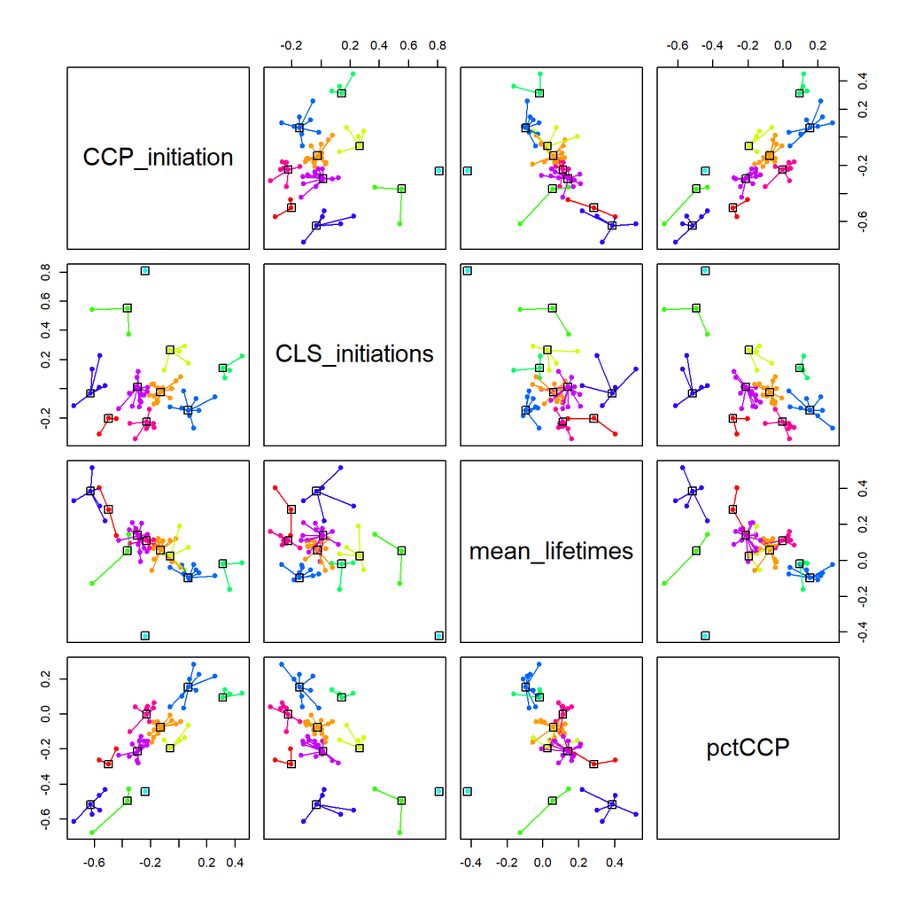

```r
library(apcluster)
apres <- apcluster(negDistMat(r=2), df_pctDiff)
plot(apres, df_pctDiff)
```

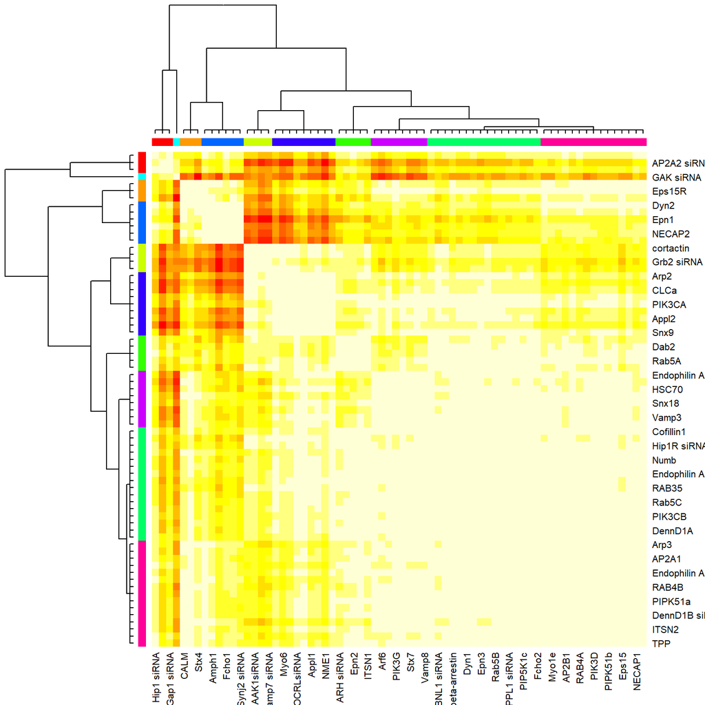

```r
heatmap(apres, cexRow=1,cexCol=1)
```

```r
library(Biobase)
no_elem <- listLen(apres@clusters)
tb_apc <- data.frame(unlist(apres@clusters))
colnames(tb_apc) <- "Cluster No."
tb_apc$`Cluster No.` <- rep(1:K, no_elem)

kable(tb_apc) %>% kable_styling("striped", full_width = F) %>% scroll_box(height = "400px")
```

|  | Cluster No. |
| --- | --- |
| CALM | 1 |
| Eps15R | 1 |
| Stx4 | 1 |
| Cofillin1 | 2 |
| DBNL1 siRNA | 2 |
| Hip1R siRNA | 2 |
| beta-arrestin | 2 |
| Numb | 2 |
| Dyn1 | 2 |
| Endophilin A3 | 2 |
| Epn3 | 2 |
| RAB35 | 2 |
| Rab5B | 2 |
| Rab5C | 2 |
| INPPL1 siRNA | 2 |
| PIK3CB | 2 |
| PIP5K1c | 2 |
| DennD1A | 2 |
| Fcho2 | 2 |
| ARH siRNA | 3 |
| Dab2 | 3 |
| Epn2 | 3 |
| Rab5A | 3 |
| ITSN1 | 3 |
| Hip1 siRNA | 4 |
| AP2A2 siRNA | 4 |
| ArfGap1 siRNA | 4 |
| cortactin | 5 |
| AAK1siRNA | 5 |
| Grb2 siRNA | 5 |
| Vamp7 siRNA | 5 |
| GAK siRNA | 6 |
| Arp2 | 7 |
| Myo6 | 7 |
| CLCa | 7 |
| OCRLsiRNA | 7 |
| PIK3CA | 7 |
| Appl1 | 7 |
| Appl2 | 7 |
| NME1 | 7 |
| Snx9 | 7 |
| Dyn2 | 8 |
| Amph1 | 8 |
| Epn1 | 8 |
| Fcho1 | 8 |
| NECAP2 | 8 |
| Synj2 siRNA | 8 |
| Arp3 | 9 |
| Myo1e | 9 |
| AP2A1 | 9 |
| AP2B1 | 9 |
| Endophilin A1 | 9 |
| RAB4A | 9 |
| RAB4B | 9 |
| PIK3D | 9 |
| PIPK51a | 9 |
| PIPK51b | 9 |
| DennD1B siRNA | 9 |
| Eps15 | 9 |
| ITSN2 | 9 |
| NECAP1 | 9 |
| TPP | 9 |
| Endophilin A2 | 10 |
| Arf6 | 10 |
| HSC70 | 10 |
| PIK3G | 10 |
| Snx18 | 10 |
| Stx7 | 10 |
| Vamp3 | 10 |
| Vamp8 | 10 |

**APC result:** The clustering is based on proteins’ similarity–it takes a similarity matrix (e.g. negative distance matrix) as its input and cluster identification is done based on the concept of “message passing” between data points. Typically, APC does not require the number of clusters to be determined or estimated before its run. Interestingly, the method detected 10 clusters automatically and these results are visualized in the form of scatter plot matrices and a heatmap. Each protein’s cluster number is listed in the table above.

$~$

#### Comparison of the clustering results

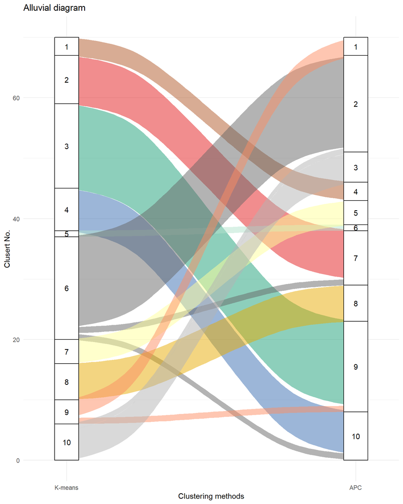

```r
tb_all <- merge(tb_km, tb_apc, by="row.names")
colnames(tb_all) <- c("Protein", "K-means", "APC")
rownames(tb_all) <- tb_all$Protein
tb_all <- tb_all[,-c(1)]
df_counts <- melt(table(tb_all))
df_counts <- df_counts[df_counts$value!=0,]

#=myColors
library(RColorBrewer)
n <- 10
qual_col_pals = brewer.pal.info[brewer.pal.info$category == 'qual',]
color_vector = unlist(mapply(brewer.pal, qual_col_pals$maxcolors, rownames(qual_col_pals)))
set.seed(1234)
myColors = sample(color_vector, n)
#======

library(ggalluvial)
df_counts$`K-means` <- as.factor(df_counts$`K-means`)
df_counts$APC <- as.factor(df_counts$APC)

ggplot(data = df_counts, aes(axis1 = `K-means`, axis2 = APC, y = value)) +
  scale_x_discrete(limits = c("K-means","APC"), expand = c(.1, .05)) +
  xlab("Clustering methods") +
  geom_alluvium(aes(fill = `K-means`), width = 0) +
  geom_stratum(width = 1/12) +
  geom_text(stat = "stratum", aes(label = after_stat(stratum))) +
  scale_fill_manual( values = myColors ) +
  theme_minimal() +
  #theme(axis.text.y=element_blank(), axis.ticks.y=element_blank()) +
  labs(y="Clusert No.") +
  theme(legend.text = element_text(size=8), legend.position='none') +
  ggtitle("Alluvial diagram")
```

$~$

#### For better comparison between K-means and APC clusters

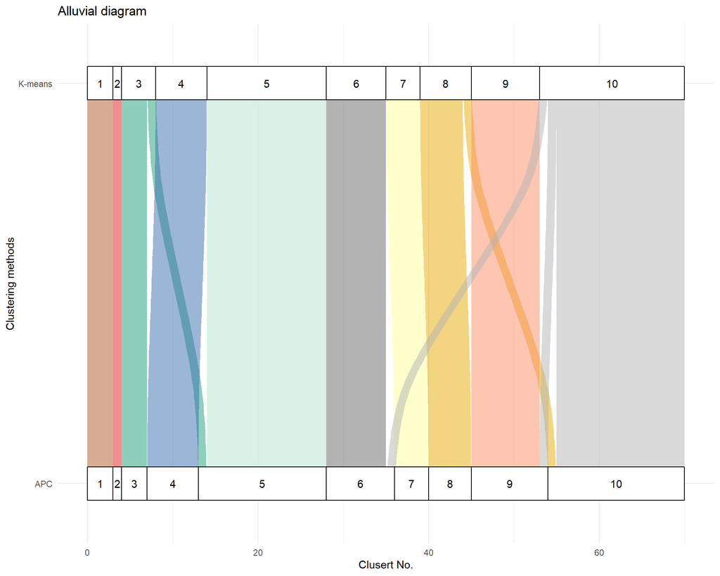

```r
# To reorder the clusters, change cluster IDs using a lookup table
lookup_km <- setNames(c(1:10), c(1, 5, 9, 8, 3, 4, 7, 10, 2, 6))
tb_km2 <- cbind(tb_km[, -1, drop = FALSE],
             data.frame(lapply(tb_km, function(i) lookup_km[ as.character(i)])))

lookup_APC <- setNames(c(1:10), c(4, 6, 1, 8, 9, 10, 5, 3, 7, 2))
tb_apc2 <- cbind(tb_apc[, -1, drop = FALSE],
             data.frame(lapply(tb_apc, function(i) lookup_APC[ as.character(i)])))

tb_all <- merge(tb_km2, tb_apc2, by="row.names")
colnames(tb_all) <- c("Protein", "K-means", "APC")
rownames(tb_all) <- tb_all$Protein
tb_all <- tb_all[,-c(1)]
df_counts <- melt(table(tb_all))
df_counts <- df_counts[df_counts$value!=0,]


library(ggalluvial)
df_counts$`K-means` <- factor(df_counts$`K-means`)
df_counts$APC <- factor(df_counts$APC)

ggplot(data = df_counts, aes(axis1 = APC, axis2 = `K-means`, y = value)) +
  scale_x_discrete(limits = c("APC", "K-means"), expand = c(.1, .05)) +
  xlab("Clustering methods") +
  geom_alluvium(aes(fill = `K-means`), width = 0, reverse=FALSE) +
  coord_flip() +
  geom_stratum(width = 1/12, reverse=FALSE) +
  geom_text(stat = "stratum", aes(label = after_stat(stratum)), reverse=FALSE) +
  scale_fill_manual( values = myColors ) +
  theme_minimal() +
  labs(y="Clusert No.") +
  theme(legend.text = element_text(size=8), legend.position='none') +
  ggtitle("Alluvial diagram")
```

**Alluvial diagram:** In an alluvial diagram, blocks represent clusters of nodes, and stream fields between the blocks represent changes in the composition of these clusters over time or clustering methods.The clusters from both methods are found very consistent.

$~$